# Selection Sort

Algoritma selection sort memiliki waktu komputasi yang lebih cepat dibandingkan dengan algoritma bubble sort. Hal ini dikarenakan terjadi reduksi waktu pada saat proses pertukaran data. Jika algoritma bubble sort, pada setiap iterasi,setiap dua data yang berdekatan akan dibandingkan, dan akan dilakukan pertukaran data jika syarat memenuhi. Maka pada algoritma selection sort tidak akan melakukan dua proses ini (perbandingan dan pertukaran) pada satu waktu, akan tetapi, pada algoritma selection sort, akan dicari data yang memenuhi syarat terlebih dahulu (perbandingan data), kemudian data yang terpilih ini ini akan diletakkan pada indeks data yang tepat. Oleh karena itu algoritma ini dinamakan selection (pemilihan data).

Berikut tahapan algoritma selection sort (ascending order):

1. Algoritma ini dimulai dari indeks awal sampai dengan indeks akhir data
2. Cari data dengan nilai paling minimal (dari indeks awal sampai dengan indeks akhir) melalui proses perbandingan
3. Letakkan data minimal ini di indeks awal
4. Ulangi lagi proses pencarian data paling minimal (dari indeks awal+1 sampai dengan indeks akhir, karena indeks awal sudah terisi data yang tepat).
5. Letakkan data ini pada indeks awal+1
6. Ulangi lagi proses pencarian data paling minimal (dari indeks awal+2 sampai dengan akhir) dan letakkan data ini pada indeks awal+2, dst.

[figure not shown]

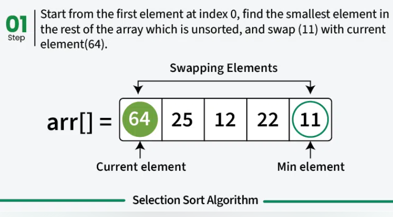

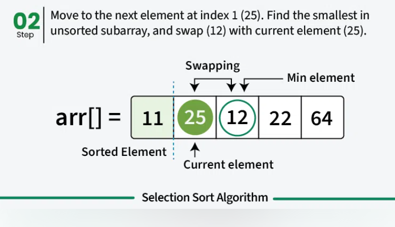

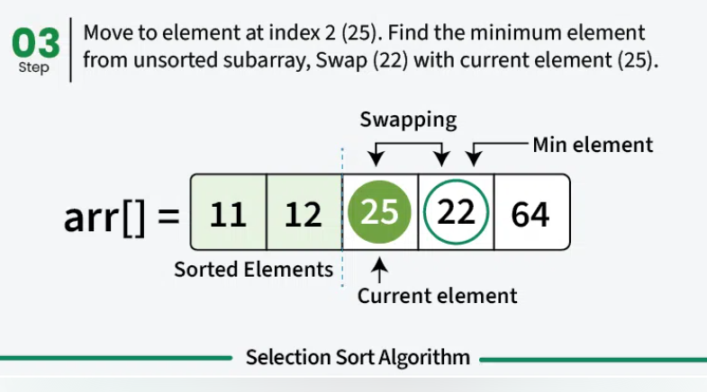

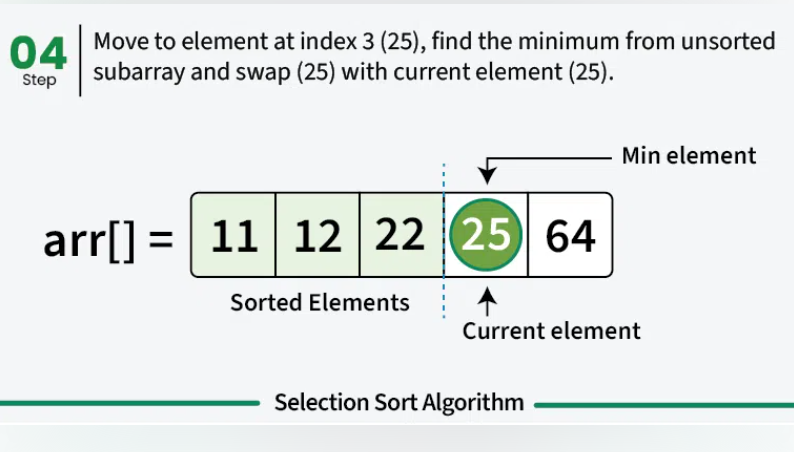

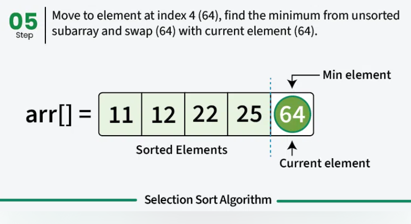

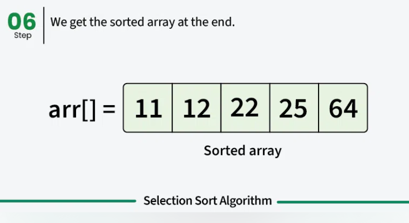

### Berikut adalah code untuk algoritma selection sort

```python
def selectionSort(listData):
    print('Algoritma Selection Sort konvensional')
    print('Data Awal=',listData)
    for outIter in range(len(listData)-1):
        minIndex=outIter
        for i in range(outIter+1,len(listData)):
            if listData[i]<listData[minIndex]:
                minIndex=i

        temp=listData[outIter]
        listData[outIter]=listData[minIndex]
        listData[minIndex]=temp
        print('Iterasi ke-',outIter+1,':',listData)
    print('Data Urut=',listData)
```

```python
a=[10,2,5,8,1,20,7,12,4]
selectionSort(a)
```

```
Algoritma Selection Sort konvensional
Data Awal= [10, 2, 5, 8, 1, 20, 7, 12, 4]
Iterasi ke- 1 : [1, 2, 5, 8, 10, 20, 7, 12, 4]
Iterasi ke- 2 : [1, 2, 5, 8, 10, 20, 7, 12, 4]
Iterasi ke- 3 : [1, 2, 4, 8, 10, 20, 7, 12, 5]
Iterasi ke- 4 : [1, 2, 4, 5, 10, 20, 7, 12, 8]
Iterasi ke- 5 : [1, 2, 4, 5, 7, 20, 10, 12, 8]
Iterasi ke- 6 : [1, 2, 4, 5, 7, 8, 10, 12, 20]
Iterasi ke- 7 : [1, 2, 4, 5, 7, 8, 10, 12, 20]
Iterasi ke- 8 : [1, 2, 4, 5, 7, 8, 10, 12, 20]
Data Urut= [1, 2, 4, 5, 7, 8, 10, 12, 20]
```

```python
def modified_selection_sort(arr):
  n = len(arr)
  print("--- Modifikasi Selection Sort ---")

  print("input  :", *arr)

  for i in range(n - 1):
    idx = i
    for j in range(i + 1, n):
      if arr[i] % 2 == arr[j] % 2:
        if arr[i] % 2 == 0:
          if arr[j] < arr[idx]:
            idx = j
        else:
          if arr[j] > arr[idx]:
            idx = j

    if idx != i:
        arr[i], arr[idx] = arr[idx], arr[i]

    print(f"Iterasi ke-{i+1}:", *arr)

  print("Tidak ada pertukaran")
  print("Array akhir:", *arr)
  print("\n")

input_arr2 = [8, 3, 6, 9, 2, 7, 4, 5]
modified_selection_sort(input_arr2)
```

```
--- Modifikasi Selection Sort ---
input  : 8 3 6 9 2 7 4 5
Iterasi ke-1: 2 3 6 9 8 7 4 5
Iterasi ke-2: 2 9 6 3 8 7 4 5
Iterasi ke-3: 2 9 4 3 8 7 6 5
Iterasi ke-4: 2 9 4 7 8 3 6 5
Iterasi ke-5: 2 9 4 7 6 3 8 5
Iterasi ke-6: 2 9 4 7 6 5 8 3
Iterasi ke-7: 2 9 4 7 6 5 8 3
Tidak ada pertukaran
Array akhir: 2 9 4 7 6 5 8 3
```

```python
def selection_sort(arr):
    n = len(arr)
    for i in range(n - 1):

        # Assume the current position holds
        # the minimum element
        min_idx = i

        # Iterate through the unsorted portion
        # to find the actual minimum
        for j in range(i + 1, n):
            if arr[j] < arr[min_idx]:

                # Update min_idx if a smaller element is found
                min_idx = j

        # Move minimum element to its
        # correct position
        arr[i], arr[min_idx] = arr[min_idx], arr[i]

def print_array(arr):
    for val in arr:
        print(val, end=" ")
    print()

if __name__ == "__main__":
    arr = [64, 25, 12, 22, 11]

    print("Original array: ", end="")
    print_array(arr)

    selection_sort(arr)

    print("Sorted array: ", end="")
    print_array(arr)
```

```
Original array: 64 25 12 22 11
Sorted array: 11 12 22 25 64
```

```python
#selection
import random
import time

a = []

for i in range(100):
    a.append(random.randint(1, 1000))

print("Data Awal")
print(a)


def selection(x):
    for i in range(len(x)):
        k = i
        for j in range(i+1, len(x)):
            if x[j] < x[k]:
                k = j

        t = x[i]
        x[i] = x[k]
        x[k] = t
    return x
s = time.time()
h = selection(a)
e = time.time()

print("\nHasil Selection Sort")
print(h)

print("\nWaktu :", e - s, "detik")
```

```
Data Awal
[237, 979, 83, 163, 212, 415, 149, 699, 774, 169, 916, 408, 214, 988, 507, 979, 609, 341, 928, 951, 851, 595, 673, 659, 39, 603, 321, 341, 262, 544, 19, 990, 832, 463, 51, 228, 59, 152, 166, 193, 358, 853, 886, 713, 846, 994, 168, 312, 760, 712, 646, 866, 374, 709, 459, 776, 566, 814, 796, 765, 557,…

Hasil Selection Sort
[19, 23, 30, 39, 51, 59, 71, 83, 111, 113, 149, 152, 163, 166, 168, 169, 193, 201, 212, 214, 228, 237, 239, 239, 241, 262, 275, 312, 321, 324, 341, 341, 350, 351, 358, 374, 382, 408, 415, 419, 459, 463, 501, 507, 507, 522, 544, 557, 566, 585, 595, 595, 603, 609, 626, 630, 646, 651, 659, 666, 673, 68…

Waktu : 0.0005016326904296875 detik
```